# RSF for sleeping sites and Moon illumination

[Index](https://valentinzarate.github.io/moon_sleeping_sites/) [Moon and Sleeping sites](https://valentinzarate.github.io/moon_sleeping_sites/moon_sleeping.html) [Buffers and Absences](https://valentinzarate.github.io/moon_sleeping_sites/moon_buffer_alternatives.html)

## 1 Resource Selection Functions (RSF)

**How does an RSF work?**

- RSF models compare environmental covariates at observed (used) sites with a set of randomly generated (available) points.
- By including both *fixed effects* (e.g., canopy height, moonlight, and their interaction) and *random effects* (e.g., individual, group, or night), we can account for both general patterns and non-independence in the data.
- The RSF typically uses a *logistic regression framework* to estimate the relative probability of site selection as a function of covariates.

## 2 Libraries

```r
set.seed(533)

library(tidyverse)
library(terra)
library(suncalc)
library(purrr)
library(hexbin)
library(viridis)
library(geosphere)
library(scales)
library(spdep)
library(performance)
library(flextable)
library(amt)
library(MuMIn)
library(showtext)
library(patchwork)
library(lme4)
library(mapview)
library(sf)
library(sjPlot)
library(DHARMa)
library(car)
library(usdm)
library(visreg)
library(tmap)
library(broom)
library(broom.mixed)
library(AICcmodavg)
```

### 2.1 Load Pre-processed Data

We start by loading a list of all data frames representing different design combinations (number of pseudo-absence points and buffer size), each already processed to include the relevant spatial and environmental covariates.

```r
all_dfs_proc <- readRDS("all_dfs_proc.rds")
```

### 2.2 Optimal Sampling Combination

From this list, we select the design previously identified as optimal (here, 10 pseudo-absence points per used location and a 300 m buffer), balancing estimator stability and minimizing spatial autocorrelation.

```r
rsf <- all_dfs_proc[["n10_b300"]]
```

```r
rsf2 <- rsf %>%
  filter(moon_light_effective_avg <= 0.6) %>%
  mutate(
    moon_bin = cut(
      moon_light_effective_avg,
      breaks = c(0, 0.02, 0.05, 0.1, 0.2, 0.4, 0.6),
      labels = c("0–0.02", "0.02–0.05", "0.05–0.1", "0.1–0.2", "0.2–0.4", "0.4–0.6"),
      include.lowest = TRUE
    )
  )

ndvi_compare <- rsf2 %>%
  group_by(moon_bin, used) %>%
  summarise(mean_ndvi = mean(ndvi_sentinel, na.rm = TRUE)) %>%
  pivot_wider(names_from = used, values_from = mean_ndvi) %>%
  rename(ndvi_disponible = `FALSE`, ndvi_usado = `TRUE`) %>%
  mutate(diff = ndvi_usado - ndvi_disponible)

print(ndvi_compare)
```

```
## # A tibble: 6 × 4
## # Groups:   moon_bin [6]
##   moon_bin  ndvi_disponible ndvi_usado     diff
##   <fct>               <dbl>      <dbl>    <dbl>
## 1 0–0.02              0.547      0.568  0.0209
## 2 0.02–0.05           0.552      0.568  0.0165
## 3 0.05–0.1            0.570      0.560 -0.0102
## 4 0.1–0.2             0.544      0.568  0.0236
## 5 0.2–0.4             0.540      0.521 -0.0193
## 6 0.4–0.6             0.543      0.534 -0.00980
```

```r
rsf$group <- as.factor(rsf$group)
rsf$fecha <- as.factor(rsf$fecha)
```

### 2.3 Prepare Covariates for Modeling

For comparability and model convergence, continuous covariates are standardized (mean-centered and scaled by standard deviation).

```r
rsf <- rsf %>%
  mutate(
    moon_light_sc = scale(moon_light_effective_avg),
    canopy_height_sc = scale(canopy_height),
    ndvi_sc = scale(ndvi_sentinel),
    pp_sc = scale(pp),
    t_max_sc = scale(t_max))
```

## 3 RSF Model Fitting

After preparing the data, we fit a series of Resource Selection Function (RSF) models to quantify how covariates affect roost-site selection probability.

**1. Null Model:**  
Baseline model with only the random effects, representing no effect of the environmental covariates. **2. Main Effects & Interaction Model:** Model testing the main effects of canopy height and moonlight, as well as their interaction. **3. Full Model:** Model including the interaction plus additional covariates (NDVI, precipitation, and max temperature) to account for further environmental influences.

```r
rsf$group <- droplevels(rsf$group)
```

```r
rsf$weights <- ifelse(rsf$used == 0, 10, 1)
```

```r
rsf_null <- glmer(
  used ~ 1 +
    (1 | group/fecha),
  data = rsf,
  weights = weights,
  family = binomial(link = "logit"))

rsf_model_height <- glmer(
  used ~ moon_light_sc * canopy_height_sc +
    (1 | group/fecha),
  data = rsf,
  weights = weights,
  family = binomial(link = "logit"))

rsf_model_conceal <- glmer(
  used ~ moon_light_sc * ndvi_sc +
    (1 | group/fecha),
  data = rsf,
  weights = weights,
  family = binomial(link = "logit"))

rsf_model_thermal <- glmer(
  used ~ canopy_height_sc * t_max_sc +
    (1 | group/fecha),
  data = rsf,
  weights = weights,
  family = binomial(link = "logit"))

rsf_model_full_inter <- glmer(
  used ~ moon_light_sc * canopy_height_sc +
    moon_light_sc * ndvi_sc +
    pp_sc* ndvi_sc +
    t_max_sc* canopy_height_sc +
    (1 | group/fecha),
  data = rsf,
  weights = weights,
  family = binomial(link = "logit"))
```

```r
models <- list(
  "Null" = rsf_null,
  "Moon X Height" = rsf_model_height,
  "Moon X NDVI" = rsf_model_conceal,
  "Thermal Confort" = rsf_model_thermal,
  "Full" = rsf_model_full_inter)

get_nparams <- function(mod) {
  length(fixef(mod)) + length(VarCorr(mod))
}
model_stats <- lapply(models, function(mod) broom.mixed::glance(mod) %>% dplyr::select(AIC, nobs))
n_params <- sapply(models, get_nparams)

summary_tab <- tibble(
  Model = names(models),
  AIC = sapply(model_stats, function(x) x$AIC),
  n_params = n_params) %>%
  mutate(
    delta_AIC = round(AIC - min(AIC), 2),
    weight = round(exp(-0.5 * delta_AIC) / sum(exp(-0.5 * delta_AIC)), 3)

  ) %>%
  arrange(AIC)

ft <- flextable(summary_tab) %>%
  autofit() %>%
  set_header_labels(
    Model = "Model",
    AIC = "AIC",
    delta_AIC = "ΔAIC",
    weight = "Weight",
    n_params = "Parameters")
ft
```

| Model | AIC | Parameters | ΔAIC | Weight |
| --- | --- | --- | --- | --- |
| Full | 4,104.011 | 12 | 0.00 | 1 |
| Moon X Height | 4,124.066 | 6 | 20.05 | 0 |
| Thermal Confort | 4,276.339 | 6 | 172.33 | 0 |
| Null | 4,314.598 | 3 | 210.59 | 0 |
| Moon X NDVI | 4,315.332 | 6 | 211.32 | 0 |

```r
summary(rsf_model_full_inter)
```

[output not shown]

### 3.1 Evaluating Model Assumptions with DHARMa

Before interpreting the results of the RSF models, it is essential to evaluate the validity of model assumptions.  
Generalized linear mixed models (GLMMs), such as our RSF, require checking for violations such as residual non-uniformity, overdispersion, and outliers, which can influence inference and lead to misleading conclusions.

We use the `DHARMa` package to simulate scaled residuals from the fitted model and visually inspect the diagnostics:

We evaluated multicollinearity among the predictor variables included in the RSF model by calculating Variance Inflation Factors (VIFs) using a linear model with the same fixed effects structure. This approach helps to identify potential redundancy or strong linear relationships between covariates that could bias parameter estimates or inflate standard errors. All predictors were standardized prior to analysis to facilitate interpretation and reduce collinearity.

```r
vif_model <- lm(
  used ~ moon_light_sc * canopy_height_sc +
         moon_light_sc * ndvi_sc +
         pp_sc * ndvi_sc +
         t_max_sc * canopy_height_sc,
  data = rsf)
vif_values <- car::vif(vif_model)


vif_df <- data.frame(
  Variable = names(vif_values),
  VIF = round(vif_values, 2))

vif_table <- flextable(vif_df)
vif_table <- autofit(vif_table)
vif_table <- set_caption(vif_table, caption = "Variance Inflation Factors (VIFs) for predictor variables")
vif_table
```

Variance Inflation Factors (VIFs) for predictor variables

| Variable | VIF |
| --- | --- |
| moon_light_sc | 1.20 |
| canopy_height_sc | 1.42 |
| ndvi_sc | 1.31 |
| pp_sc | 1.12 |
| t_max_sc | 1.02 |
| moon_light_sc:canopy_height_sc | 1.45 |
| moon_light_sc:ndvi_sc | 1.42 |
| ndvi_sc:pp_sc | 1.13 |
| canopy_height_sc:t_max_sc | 1.01 |

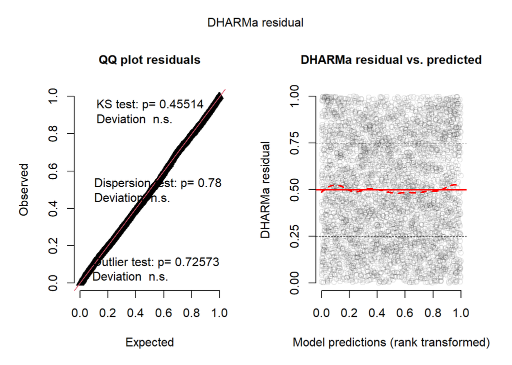

```r
sim_res <- simulateResiduals(rsf_model_full_inter, n = 1000)
plot(sim_res)
```

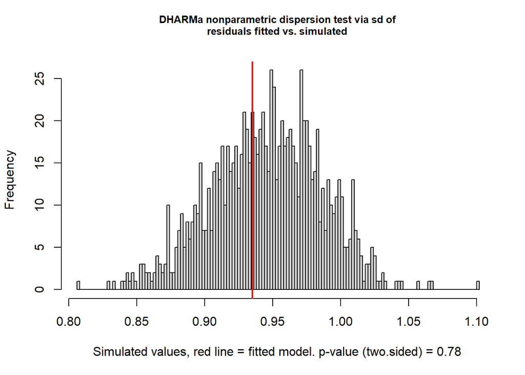

```
##
##  DHARMa nonparametric dispersion test via sd of residuals fitted vs.
##  simulated
##
## data:  simulationOutput
## dispersion = 0.98892, p-value = 0.78
## alternative hypothesis: two.sided
```

```r
testDispersion(sim_res)
```

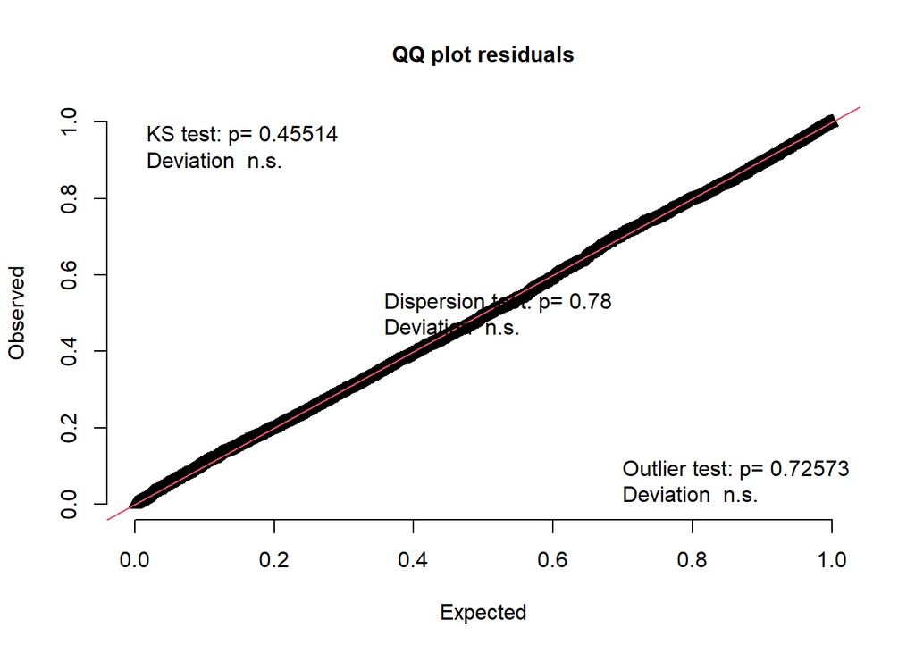

```
##
##  Asymptotic one-sample Kolmogorov-Smirnov test
##
## data:  simulationOutput$scaledResiduals
## D = 0.013338, p-value = 0.4551
## alternative hypothesis: two-sided
```

```r
testUniformity(sim_res)
```

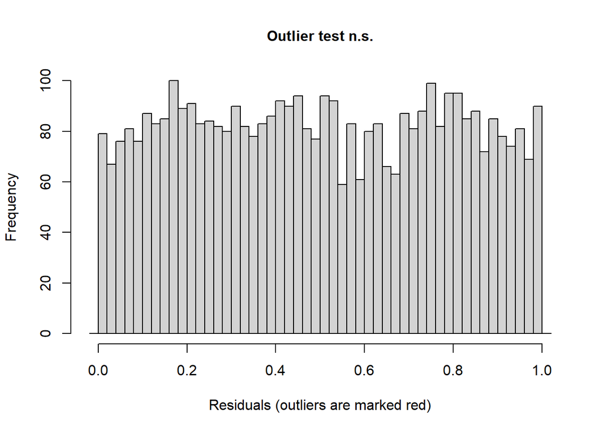

```
##
##  DHARMa outlier test based on exact binomial test with approximate
##  expectations
##
## data:  sim_res
## outliers at both margin(s) = 9, observations = 4126, p-value = 0.7257
## alternative hypothesis: true probability of success is not equal to 0.001998002
## 95 percent confidence interval:
##  0.0009978944 0.0041367105
## sample estimates:
## frequency of outliers (expected: 0.001998001998002 )
##                                          0.002181289
```

```r
testOutliers(sim_res)
```